# 231B - Section 8

Natalia Garbiras Díaz

March 16, 2017

# Today:

- Brief note on diff in diffs
- Clustering
- OLS vs GLS

# Difference in differences

What do coefficient plots for the difference tell us about the test statistic for the difference in differences?

Cases when the confidence intervals overlap vs. when they don’t.

# Clustering

DGP

```r
m <- 80 # cluster size
C <- 100 # nr of clusters
N <- m*C
cl <- rep(1:C, each=m)

y_0 <- c(rnorm(N/8, 0, 2), rnorm(N/4, 3, 2), rnorm(N/4, 5, 1),
         rnorm(N/4, 7, 1), rnorm(N/8, 8, 2))
y_1 <- y_0 + rnorm(N, 3, 1)
```

What is the average causal effect?

```r
ACE <- mean(y_1) - mean(y_0)
ACE
```

```
## [1] 3.000653
```

We will assign 4000 units to treatment and 4000 to control

```r
simulation <- function(){

    simple_random <- sample(c(rep(1, N/2), rep(0, N/2)), N, replace=F)

    clusters_treat <- sample(1:C, C/2, replace=FALSE)


    g <- function(x) {sum(x==clusters_treat)}

    cluster_random <- unlist(lapply(cl, FUN=g))

    # diff in means simple random assignment
    dm_sr <- mean(y_1[simple_random==1]) - mean(y_0[simple_random==0])

    # diff in means cluster assignment, individual
    dm_cl <- mean(y_1[cluster_random==1]) - mean(y_0[cluster_random==0])

    # diff in means cluster assignment, cluster means
    cl_treat <- unlist(lapply(clusters_treat, FUN=function(x) mean(y_1[cl==x])))
    cl_control <- unlist(lapply(as.vector(1:C)[-(clusters_treat)],
                                 FUN=function(x) mean(y_0[cl==x])))
    dm_cl_cl <- mean(cl_treat) - mean(cl_control)

    return(c(dm_sr, dm_cl, dm_cl_cl))

}
```

```r
simulation()
```

```
## [1] 3.019011 2.621954 2.621954
```

```r
sims <- replicate(10000, simulation())
```

How do we expect the results to lool like?

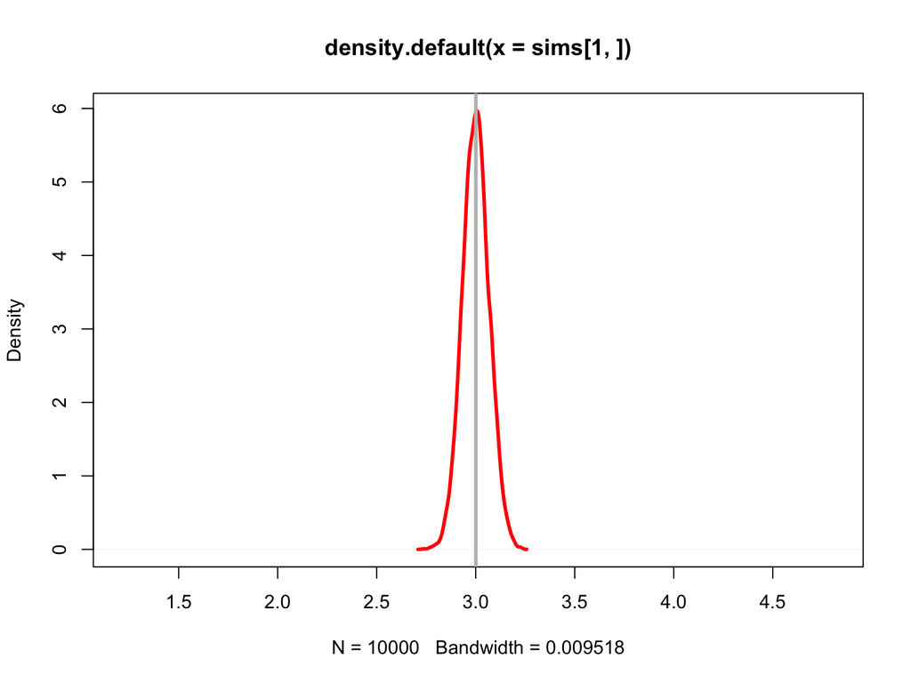

```r
plot(density(sims[1, ]), col="red", lwd=3, xlim=c(min(sims),max(sims)))
abline(v=ACE, col="grey", lwd=3)
```

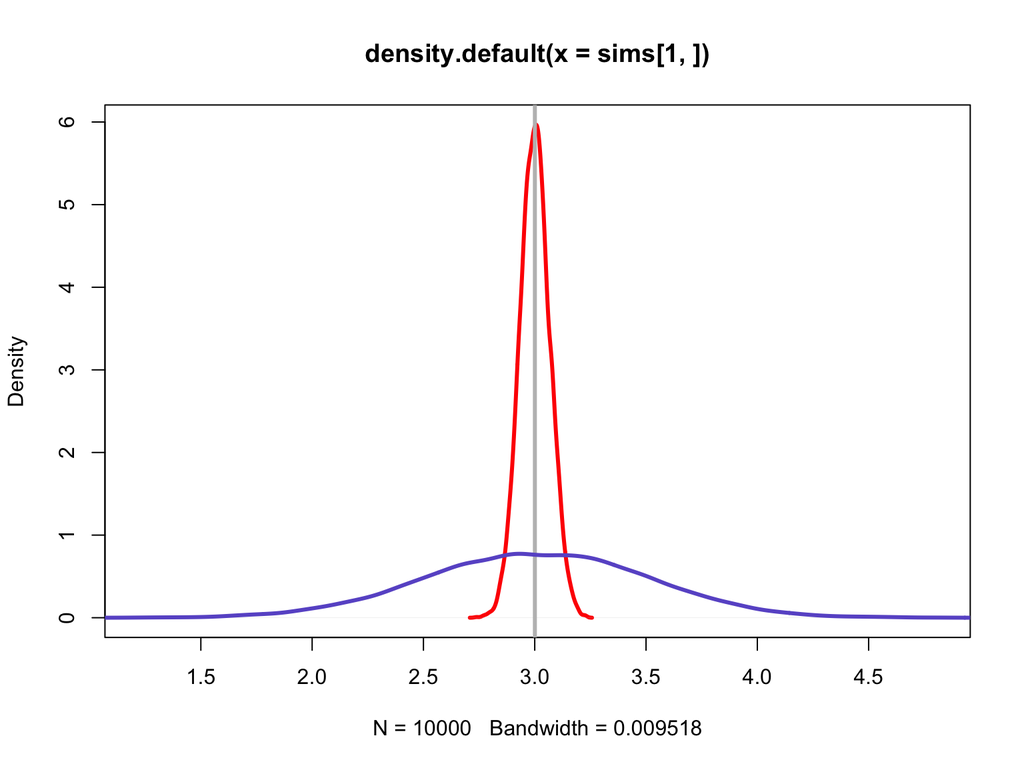

```r
plot(density(sims[1, ]), col="red", lwd=3, xlim=c(min(sims),max(sims)))
abline(v=ACE, col="grey", lwd=3)
lines(density(sims[2, ]), col="slateblue", lwd=3)
```

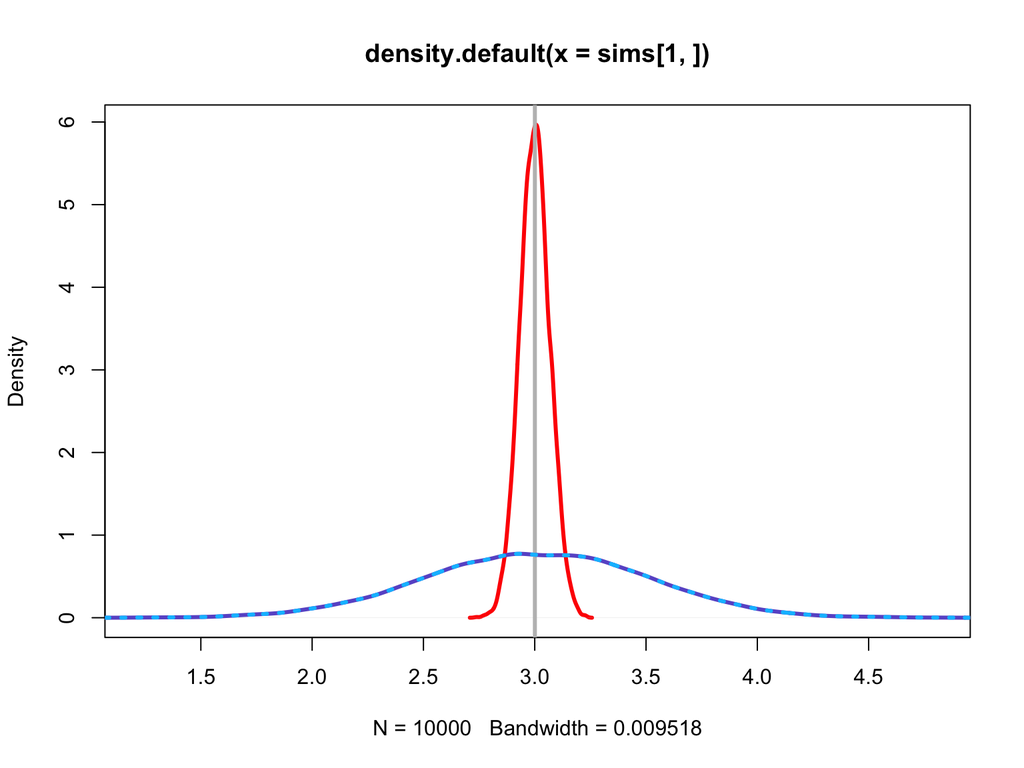

```r
plot(density(sims[1, ]), col="red", lwd=3, xlim=c(min(sims),max(sims)))
abline(v=ACE, col="grey", lwd=3)
lines(density(sims[2, ]), col="slateblue", lwd=3)
lines(density(sims[3, ]), col="deepskyblue", lwd=3, lty=3)
```

```r
apply(sims, MARGIN=1, FUN=mean)
```

```
## [1] 3.000788 3.005370 3.005370
```

```r
apply(sims, MARGIN=1, FUN=sd)
```

```
## [1] 0.06718187 0.50069004 0.50069004
```

# The problem: OLS and Heteroscedasticity

Setup

```r
y_0 <- rnorm(100, 0, 1)
y_1 <- y_0 + rnorm(100, 2, 10)

sd(y_0)
```

```
## [1] 1.070361
```

```r
sd(y_1)
```

```
## [1] 9.444176
```

```r
treat <- rbinom(100, 1, .5)
Y <- ifelse(treat==1, y_1, y_0)
```

```r
source("~/Dropbox/Academic/R/R_Functions/t_test.R")
ttest(Y, treat)
```

```
##      Mean 1      Mean 0  Difference     SE Diff      t-stat           N
##  -0.3354391  -0.1055097  -0.2299294   1.3092943  -0.1756132 100.0000000
##          df     p-value
##  55.4506175   0.8612375
```

```r
summary(lm(Y~treat))
```

```
##
## Call:
## lm(formula = Y ~ treat)
##
## Residuals:
##      Min       1Q   Median       3Q      Max
## -30.8558  -1.4680  -0.0589   1.5429  20.8962
##
## Coefficients:
##             Estimate Std. Error t value Pr(>|t|)
## (Intercept)  -0.1055     1.0721  -0.098    0.922
## treat        -0.2299     1.4456  -0.159    0.874
##
## Residual standard error: 7.192 on 98 degrees of freedom
## Multiple R-squared:  0.0002581,  Adjusted R-squared:  -0.009943
## F-statistic: 0.0253 on 1 and 98 DF,  p-value: 0.874
```

As you have shown in the last problem set, it will often be the case in experiments that
$$E(\epsilon|T) \not= \sigma^2$$
Indeed,
$$E(\epsilon_i|T_i=1)=Var(Y_i(1))$$
$$E(\epsilon_i|T_i=0)=Var(Y_i(0))$$
which are only equal when
$$Var(Y_i(1))=Var(Y_i(0))$$

Back to section 4. How do we calculate $SE(\hat{\beta})$ when we assume homoskedasticity?

```r
# The first thing we will need here is to build the matrix for X
X <- cbind(1, treat)

# getting the betas
betas <- solve(t(X)%*%X) %*% t(X)%*%Y

# and the residuals
e <- Y - X %*% betas

# and now we want the estimated sigma squared
hat_sigma2 <- sum(t(e)%*%e) / (nrow(X)-length(betas))

# and we can find estimated standard errors from $\hat{\sigma^2}(X'X)^{-1}$.
var_hat_beta <- hat_sigma2 * solve((t(X)%*%X)) # Why do we use * instead of %*% here?

# and get the SEs for our betas
se_hat_beta <- sqrt(diag(var_hat_beta))
se_hat_beta
```

```
##             treat
## 1.072095 1.445612
```

# The White-Huber correction

$$\hat{cov}(\hat{\beta})=(X'X)^{-1}(X'\hat{G}X)(X'X)^{-1}$$

The shortcut

```r
library(sandwich)
sqrt(vcovHC(lm(Y~treat), type="HC0")[2,2])  #HC: HW's estimator
```

```
## [1] 1.297302
```

Let’s go through what happens under the hood:

1. First get the square of the residuals

```r
e <- Y - X %*% betas
e2 <- (e)^2
```

2. Then, we can calculate $\widehat{G}$

```r
Ghat <- diag(lm(Y ~ treat)$residuals)^2
```

… And ``butter’’:

```r
butter <- t(X) %*% Ghat %*% X
```

3. Now we need the ``bread’’: $(X'X)$

```r
bread <- solve(t(X) %*% X)
```

# Putting everything together… the Huber-White’s correction

```r
EHW <- bread %*% butter %*% bread
```

What elements from this matrix do we need?

```r
sqrt(EHW[2,2])
```

```
## [1] 1.297302
```

Let’s compare this to the results from the t-test:

```r
ttest(Y, treat)
```

```
##      Mean 1      Mean 0  Difference     SE Diff      t-stat           N
##  -0.3354391  -0.1055097  -0.2299294   1.3092943  -0.1756132 100.0000000
##          df     p-value
##  55.4506175   0.8612375
```